# Immunological single-cell analysis of mononuclear cord blood cells

Elena Melnik

05 07 2021

## This tutorial was made as part of the course “Single-cell data analysis” from GenomicsUa (http://genomics.org.ua/2021/03/training-course-in-single-cell-biology/)

Task: To identify the contained cells from a sample of umbilical cord blood.

# Introduction

Analysis of the signal of RNA and proteins. To prepare a library, you need to take a tissue sample, such as a blood sample. Further, this sample is marked with special antibodies that bind to special surface proteins. These antibodies are linked to an oligonucleotide sequence, and this sequence also has a barcode and polyA tail that is unique for each antibody. Thanks to this sequence, it is possible to identify antibodies that bind to the protein and perform reverse transcription. As a result, we get a library of expression of genes and surface proteins.

Downloading the necessary packages and libraries for analysis

```r
library(Seurat)
library(dplyr)
```

```r
library(tidyr)
library(ggplot2)
```

Designating the size of the plots

```r
options(repr.plot.width=11, repr.plot.height=11)
```

Loading two datasets. AB - antibodies, GEX - gene expression

```r
#load in the counts matrices
cbmc.rna <- read.csv(file = './GEX_counts.csv', row.names = 1)
cbmc.ab <- read.csv(file = './AB_counts.csv', row.names = 1)
```

Preparation in data analysis with R special package. RNA-array creation. There are 2390 samples and 20501 genes in them

```r
# creates a Seurat object based on the scRNA-seq data
cbmc <- CreateSeuratObject(counts = cbmc.rna)
cbmc
```

```
## An object of class Seurat
## 20501 features across 2390 samples within 1 assay
## Active assay: RNA (20501 features, 0 variable features)
```

```r
# The cbmc object contains an assay storing RNA measurement
Assays(cbmc)
```

```
## [1] "RNA"
```

AB-array creation. Combining two arrays

```r
# create a new assay to store ab information
ab_assay <- CreateAssayObject(counts = cbmc.ab)

# add this assay to the previously created Seurat object
cbmc[["ab"]] <- ab_assay

# Validate that the object now contains multiple assays
Assays(cbmc)
```

```
## [1] "RNA" "ab"
```

Antibody proteins names in the array.

```r
#look into the feature names in the AB-assay data
rownames(cbmc[["ab"]])
```

```
##  [1] "CD3"    "CD4"    "CD8"    "CD45RA" "CD56"   "CD16"   "CD10"   "CD11c"
##  [9] "CD14"   "CD19"   "CD34"   "CCR5"   "CCR7"
```

Quality control of removing dead cells and cells with excess nucleotide sequences from the dataset. Finding out the percentage of mitochondrial genes.

```r
# The number of features and UMIs (nFeature_RNA and nCount_RNA) are automatically calculated for every object by Seurat.
# We calculate the percentage of mitochondrial features here and store it in object metadata as `percent.mito`.
# We use raw count data since this represents non-transformed and non-log-normalized counts
# The % of UMI mapping to MT-features is a common scRNA-seq QC metric.
mito.features <- grep(pattern = "^MT-", x = rownames(x = cbmc), value = TRUE)
percent.mito <- Matrix::colSums(x = GetAssayData(object = cbmc, slot = 'counts')[mito.features, ]) / Matrix::colSums(x = GetAssayData(object = cbmc, slot = 'counts'))
```

If the cells are dead, mitochondrial transcripts are released into the cytoplasm, which is why they need to be filtered. The visualization can be seen using the violin plot. The number of mitochondrial genes is about 3%, which indicates the high quality of the data set. nFeature_RNA: the number of genes nCount_RNA: the number of reads

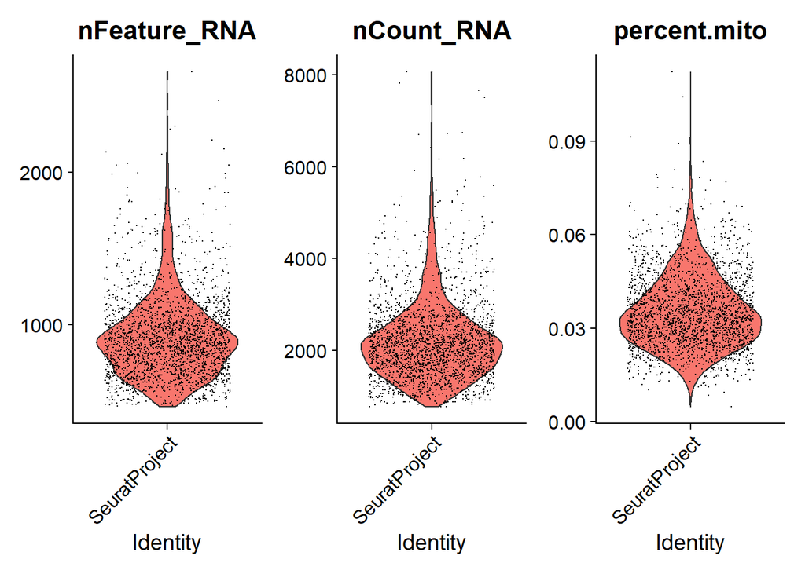

```r
# The [[ operator can add columns to object metadata, and is a great place to stash QC stats
cbmc[['percent.mito']] <- percent.mito
VlnPlot(object = cbmc, features = c("nFeature_RNA", "nCount_RNA", "percent.mito"), ncol = 3, pt.size = 0.01)
```

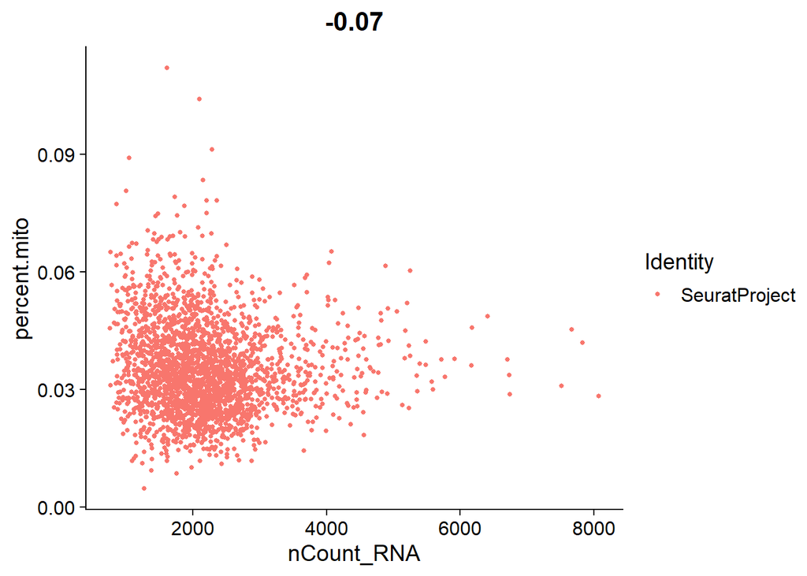

```r
# FeatureScatter is typically used to visualize feature-feature relationships, but can be used for anything
# calculated by the object, i.e. columns in object metadata, PC scores etc.
FeatureScatter(object = cbmc, feature1 = "nCount_RNA", feature2 = "percent.mito")
```

Construction of the dependence of the number of genes on the number of readings. The type of the graph is a straight line, which indicates a linear correlation. Given the plots, there is no longer any need for filtering.

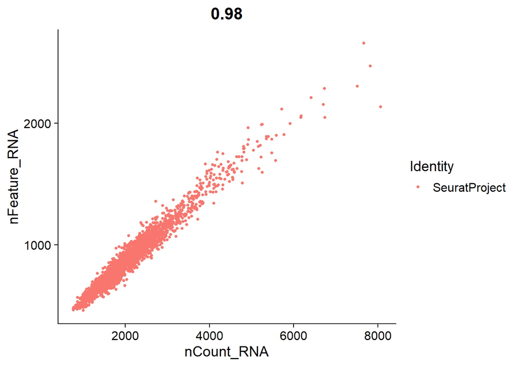

```r
#visualise the UMI and genes distribution
FeatureScatter(object = cbmc, feature1 = "nCount_RNA", feature2 = "nFeature_RNA")
```

Working with the 2 created data arrays.

```r
#First QC step done!
cbmc
```

```
## An object of class Seurat
## 20514 features across 2390 samples within 2 assays
## Active assay: RNA (20501 features, 0 variable features)
##  1 other assay present: ab
```

Scaling the data ## Cluster and visualize cells using the usual scRNA-seq workflow, and examine for the potential presence of batch effects. The normalization method used in the antibody array ‘CLR’ is different from RNA ‘LogNormalize.’ There are significant differences between preparing an antibody library when we do less amplification and an RNA library.

```r
#with the help of this command you can switch into the AB assay
DefaultAssay(cbmc) <- 'ab'
#normalize and scale the AB assay
cbmc <- NormalizeData(object = cbmc, assay = "ab", normalization.method = "CLR")
```

```
## Normalizing across features
```

```r
cbmc <- ScaleData(cbmc, assay = "ab")
```

Switch back to the RNA array.

```r
#put the AB assay aside, let's continue with the RNA assay
#with the help of this command you can switch into the RNA assay
DefaultAssay(cbmc) <- 'RNA'
```

```r
#Normalize your RNA assay
cbmc <- NormalizeData(object = cbmc, normalization.method = "LogNormalize", scale.factor = 1e4)
```

Filtrating only high variance genes in cells since only these genes will help us explain the diversity of our cells and later designate the type of cells. Using the VST method and set the number of genes to be found - 2000. We also remove ribosomal genes, as they cannot help explain the diversity of cells and harm the result. To do this, we look for all genes that begin with RPL and RPS and delete them. We can see that at first, there were 2000 genes, and after the removal, it became 10 less or 1990

```r
#FindVariable Features, remove the ribosomal genes from the variable features
cbmc <- FindVariableFeatures(cbmc, selection.method = "vst", nfeatures = 2000)
length(x = VariableFeatures(object = cbmc))#length before removal
```

```
## [1] 2000
```

```r
markers.remove <- grep(pattern = "^RPL|^RPS",  x = rownames(x = cbmc), value = TRUE)#identify ribosomal genes
VariableFeatures(object = cbmc) <- VariableFeatures(object = cbmc)[!(VariableFeatures(object = cbmc)%in%markers.remove)]#remove them from the Variable Features
length(VariableFeatures(object = cbmc))#length after removal
```

```
## [1] 1990
```

```r
# Identify the 20 most highly variable genes
top20 <- head(VariableFeatures(cbmc), 20)

# plot variable features with and without labels
plot1 <- VariableFeaturePlot(cbmc)
plot2 <- LabelPoints(plot = plot1, points = top20, repel = TRUE)
```

```
## When using repel, set xnudge and ynudge to 0 for optimal results
```

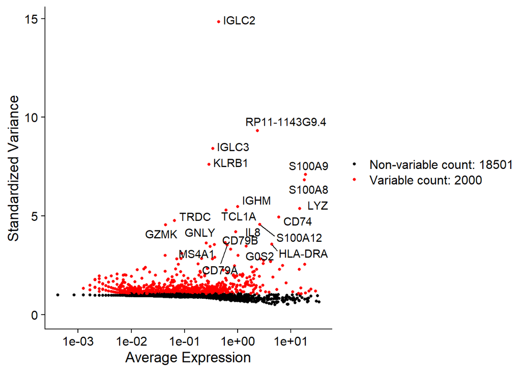

```r
plot2
```

First-dimensional reduction with the help of PCA (Principal Component Analysis). We can see the names of the genes that are expressed

```r
#Scale RNA assay, run PCA on the RNA assay
cbmc <- ScaleData(cbmc, features = VariableFeatures(cbmc))
cbmc <- RunPCA(cbmc, features = VariableFeatures(object = cbmc))
```

```
## PC_ 1
## Positive:  LTB, EVL, CD69, TRBC2, LDHB, IL32, CD3D, IL7R, CD3E, TRAC
##     PTPRCAP, CD7, ITM2A, AES, TXNIP, KLF2, LCK, PCED1B-AS1, CD3G, NOSIP
##     IFITM1, GYPC, CD27, LEF1, RHOH, PIK3IP1, LINC00861, JUN, IL2RG, ISG20
## Negative:  LYZ, TYROBP, S100A8, CST3, S100A9, FCN1, LGALS1, FTL, S100A12, MNDA
##     VCAN, FCER1G, CFD, LST1, S100A11, NEAT1, CTSS, AP1S2, S100A4, FTH1
##     SRGN, TSPO, S100A6, MS4A6A, SAT1, IFI30, GPX1, GSTP1, CEBPB, RP11-1143G9.4
## PC_ 2
## Positive:  CD3D, IL32, IL7R, CD3E, TRAC, CD7, NOSIP, ITM2A, TRBC2, AIF1
##     CD3G, LDHB, TOB1, LEF1, CD27, IFITM1, LINC00861, LCK, TNFAIP3, ANXA1
##     CORO1B, S100A6, CD2, PRKCQ-AS1, DDIT4, OXNAD1, GZMM, PIK3IP1, CAMK4, ZFP36L2
## Negative:  IGHM, TCL1A, CD79A, MS4A1, CD79B, IGHD, HLA-DQA1, HLA-DPB1, VPREB3, CD74
##     HLA-DPA1, LINC00926, HLA-DRA, RP5-887A10.1, IGJ, HLA-DQB1, HLA-DRB1, FCRLA, SMIM14, BANK1
##     IGLC3, HLA-DRB5, HLA-DOB, SPIB, CD19, PPP1R14A, FAM129C, CD37, IRF8, PDLIM1
## PC_ 3
## Positive:  DACT1, ADTRP, CMTM2, CD40LG, FAM13A, FTH1, S100A12, RBP7, S100A8, DUSP6
##     ALDH1A1, MXI1, MAL, AQP9, BCL2A1, EPHB6, RP11-356J5.12, ANKRD28, TREM1, IL8
##     RGS18, USP10, S100A11, MIR24-2, AIF1, GPA33, ANKRD55, CYP1B1, H1F0, FTL
## Negative:  DUSP2, CTSW, CD8B, CD8A, S100B, ID2, ACTG1, ACTB, ZFP36, KLRB1
##     TRGC2, NR4A2, FAM173A, HSP90AB1, AC092580.4, ZFP36L2, CCL5, ZNF331, SNHG15, VIM
##     NELL2, TNFAIP3, TOB1, MT2A, NKG7, C12orf75, PLAC8, SERPINF1, PTPRCAP, NCR3
## PC_ 4
## Positive:  CD8B, CD8A, CTSW, S100B, FAM173A, FBLN2, TRGC2, SERPINF1, CLIC3, KLRB1
##     AC092580.4, ACTB, TSPAN32, HAGHL, CXCR3, NCR3, IL2RB, NT5E, C12orf75, MT1F
##     CCL5, IGFBP2, STAG3, CHI3L2, GZMK, GPR155, METRN, DBN1, TUBB2A, TRDC
## Negative:  GPR183, USP10, SOCS3, CORO1B, TRAT1, FAM13A, DACT1, SLC40A1, GPR171, JUNB
##     AP3M2, CD40LG, ARID5B, PIM1, SOCS2, ANXA1, CYLD, DDIT4, TXNIP, GZMA
##     IL4R, DPP4, FHIT, IL7R, ARL4C, LDHB, MXI1, RP4-594I10.3, UCP2, XBP1
## PC_ 5
## Positive:  TSC22D3, LGALS2, JUNB, KLF6, CXCR4, IFITM3, FTH1, CD97, PPP1R15A, ZFP36L2
##     ZFP36, DUSP1, NR4A2, HLA-DQB1, TNFAIP3, HLA-DRB1, FOS, CPVL, DUSP6, ZNF331
##     NFKBIA, FOSB, CYP27A1, CD69, HLA-DRA, TPPP3, LMNA, ANKRD28, NELL2, ISG15
## Negative:  RETN, ACTG1, RNASE2, PADI4, HMGB2, PKM, GAPDH, PLBD1, CAPG, MGST1
##     ALOX5AP, ID1, SERPINB1, C19orf59, QPCT, CTSD, GYG1, VIM, SOX4, PGD
##     MS4A4A, OSM, HP, MEGF9, SULT1A1, S100A12, ITM2C, HMGA1, MIR4435-1HG, MTMR11
```

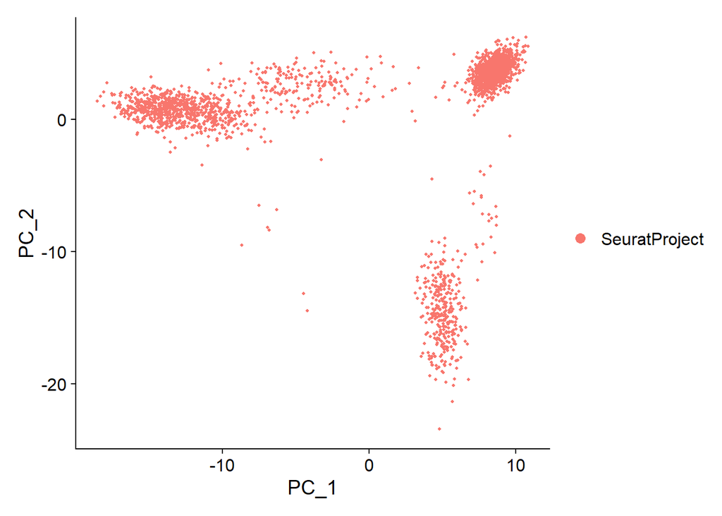

```r
DimPlot(cbmc)
```

Elbow plotting is a selection of only one of the 50 dimensions of the PCA. Visualization standard deviation of each PC. We can observe a large standard deviation on the graph initially, and further along the x-axis, it does not increase. As a result, we conclude that the point after which further values can be discarded due to the insignificant variety of cells should be right after the elbow. 10 dimensions will be used for further dimension reduction.

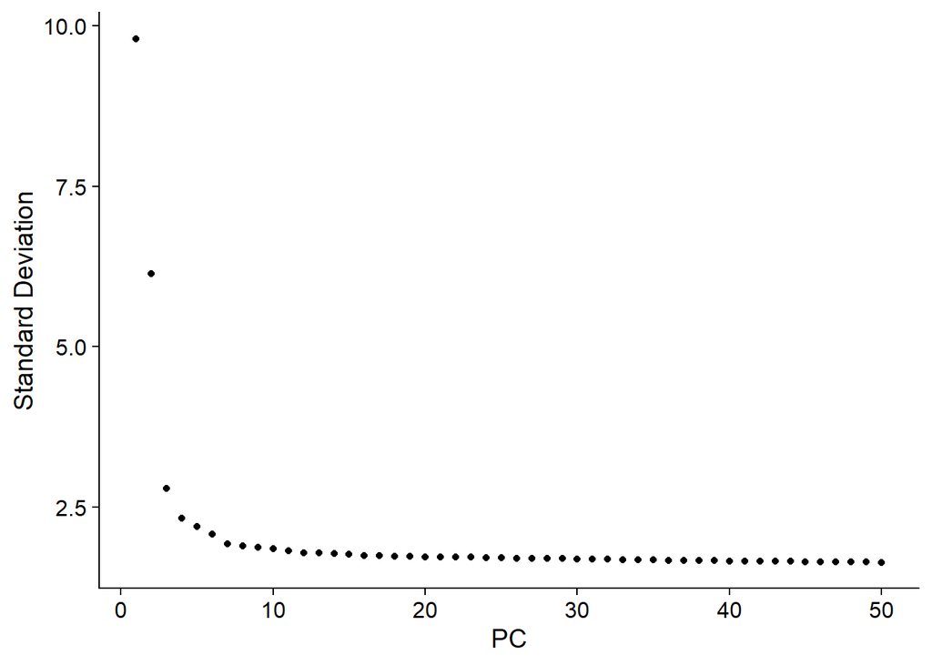

```r
#look into the ellbow plot to determine the number of the PCs
ElbowPlot(object = cbmc, ndims = 50)
```

Visualizing the genes of each dimension calculated by principal component analysis using a heatmap. Generation of 20 graphs for each dimension. On the first map, 4 zones can be clearly distinguished, a clear zone for positive and negative PCs. According to the previous graph of the dependence of the standard deviation on the PCs, we should cut off all dimensions from 9 onwards. In any case, it is worth reviewing all heatmaps and deciding whether they make sense. For example, heat map 10 shows the cytokine gene CCL5 released by a large number of immune cells, which can be described as T cells. Therefore, they are also important for us in this dimensionality reduction. DASP2 is a gene involved in the Negative Feedback Regulation of T Cells that important for complexity. CD8As (Cluster of Differentiation 8a) or CD8-positive T cells that are a critical subpopulation of MHC class I-restricted T cells and are mediators of adaptive immunity. Since heatmap 10 contains genes important for complexity, we will cut off all points after it according to the elbow plotting. From the 12th heat map, we no longer see the differences between cells.

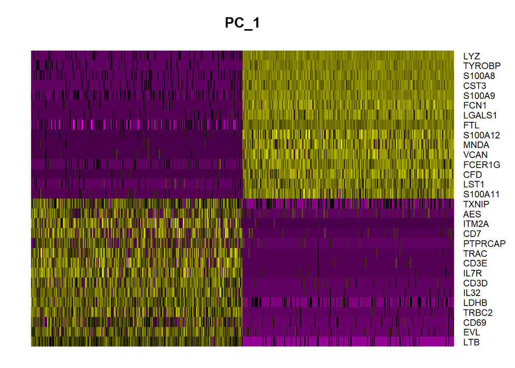

```r
#look into the Heatmap to determine the number of the PCs
DimHeatmap(object = cbmc, dims = 1, cells = 500, balanced = TRUE)
```

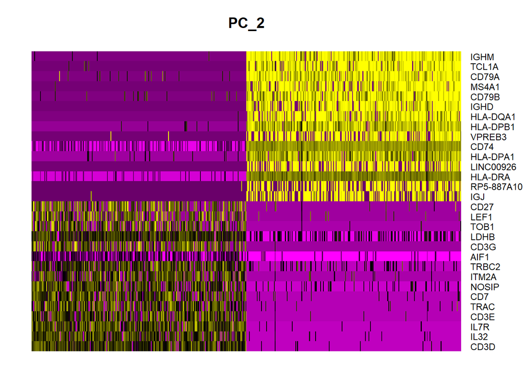

```r
DimHeatmap(object = cbmc, dims = 2, cells = 500, balanced = TRUE)
```

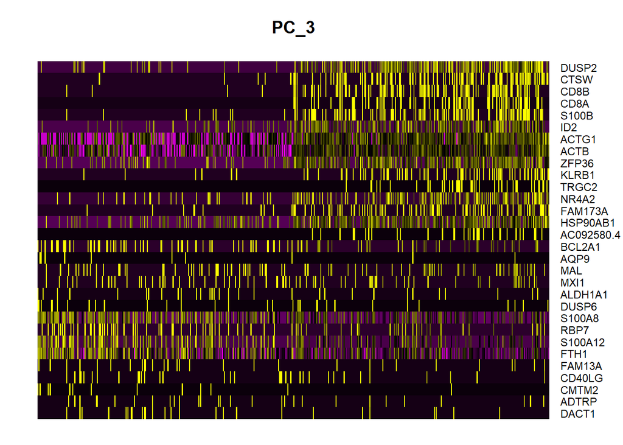

```r
DimHeatmap(object = cbmc, dims = 3, cells = 500, balanced = TRUE)
```

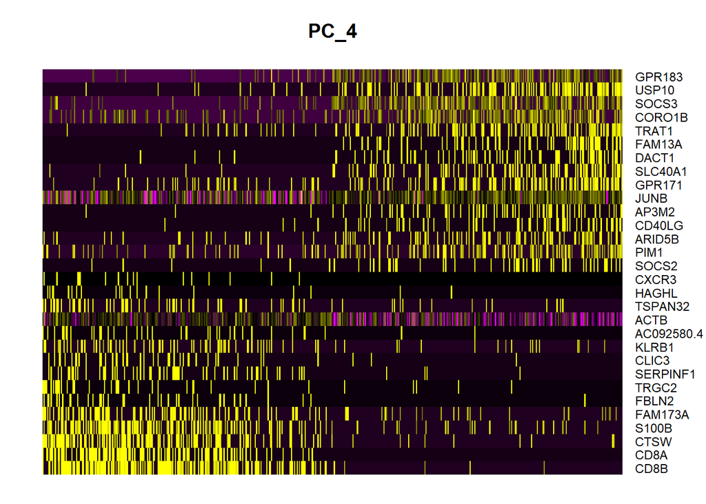

```r
DimHeatmap(object = cbmc, dims = 4, cells = 500, balanced = TRUE)
```

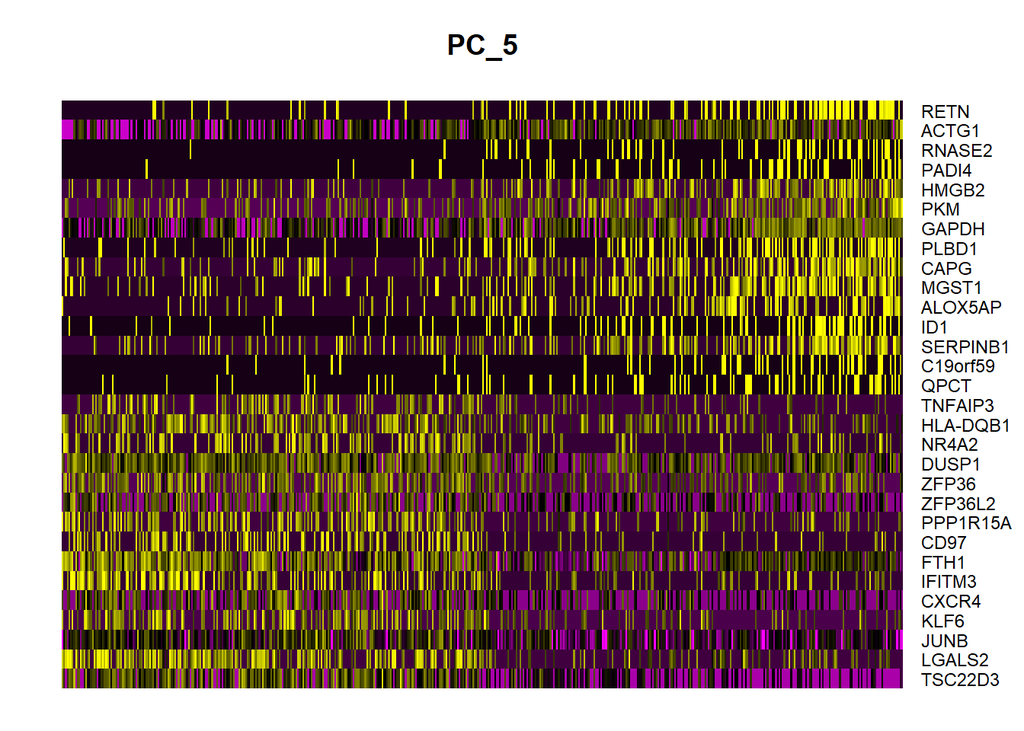

```r
DimHeatmap(object = cbmc, dims = 5, cells = 500, balanced = TRUE)
```

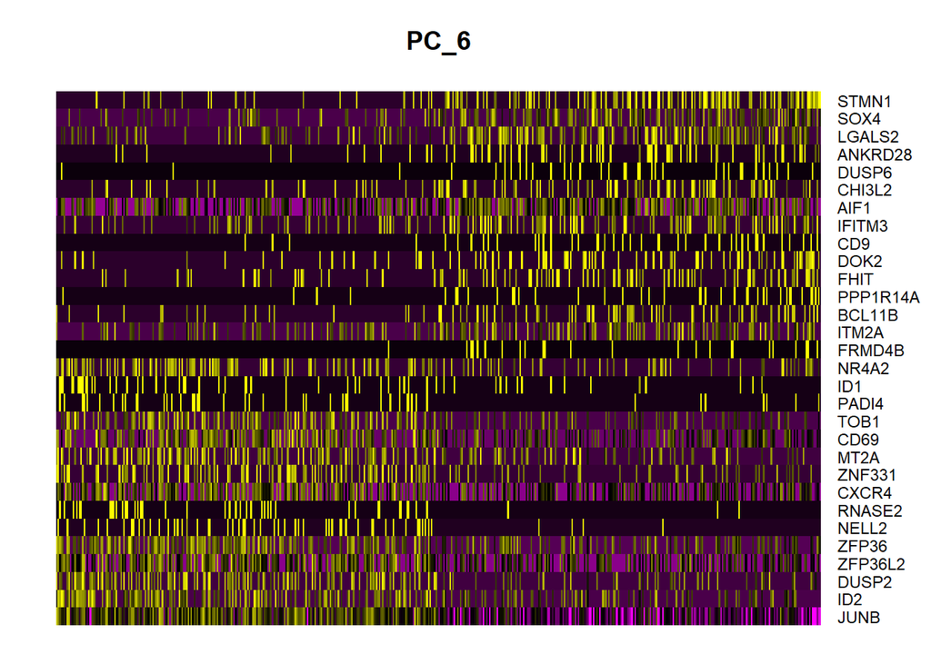

```r
DimHeatmap(object = cbmc, dims = 6, cells = 500, balanced = TRUE)
```

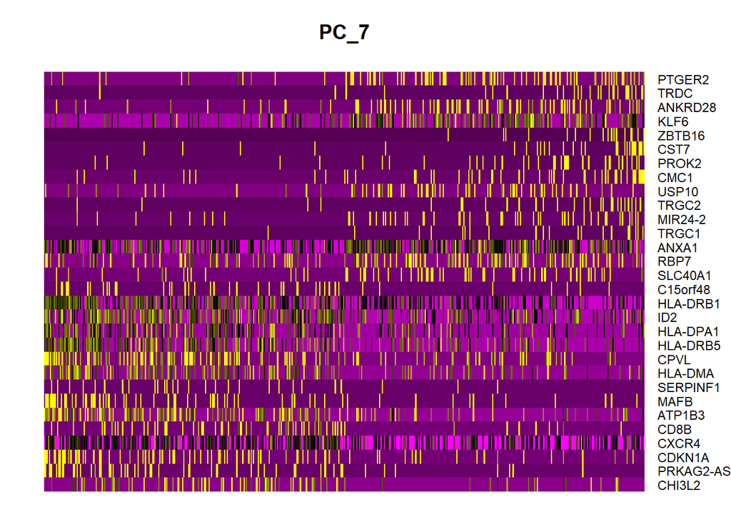

```r
DimHeatmap(object = cbmc, dims = 7, cells = 500, balanced = TRUE)
```

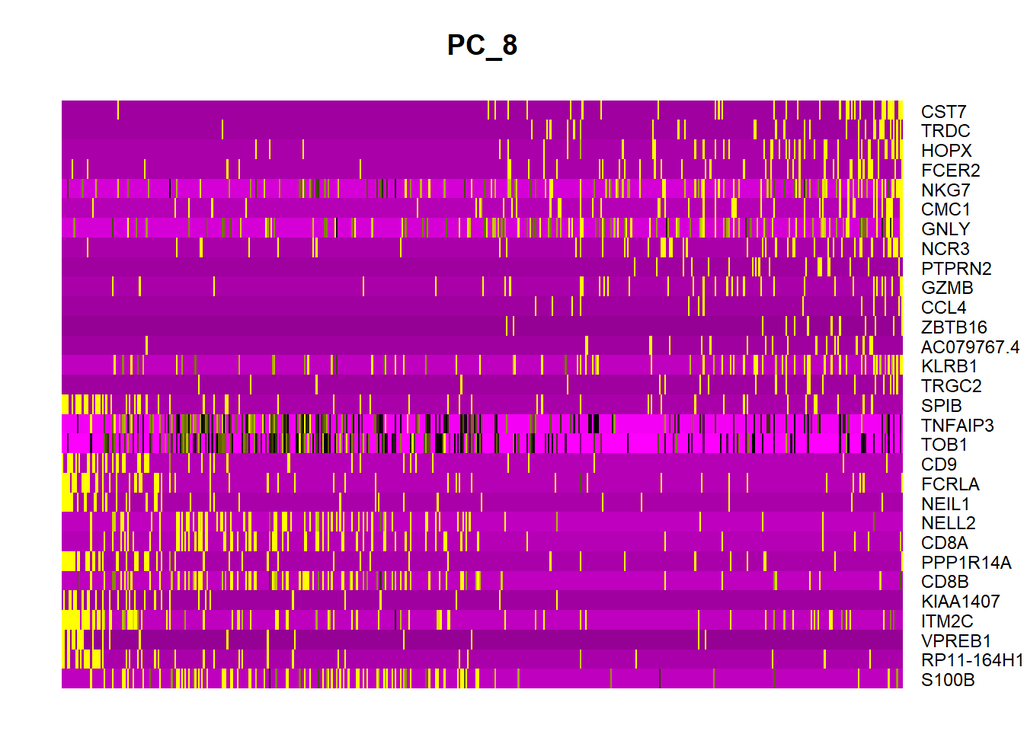

```r
DimHeatmap(object = cbmc, dims = 8, cells = 500, balanced = TRUE)
```

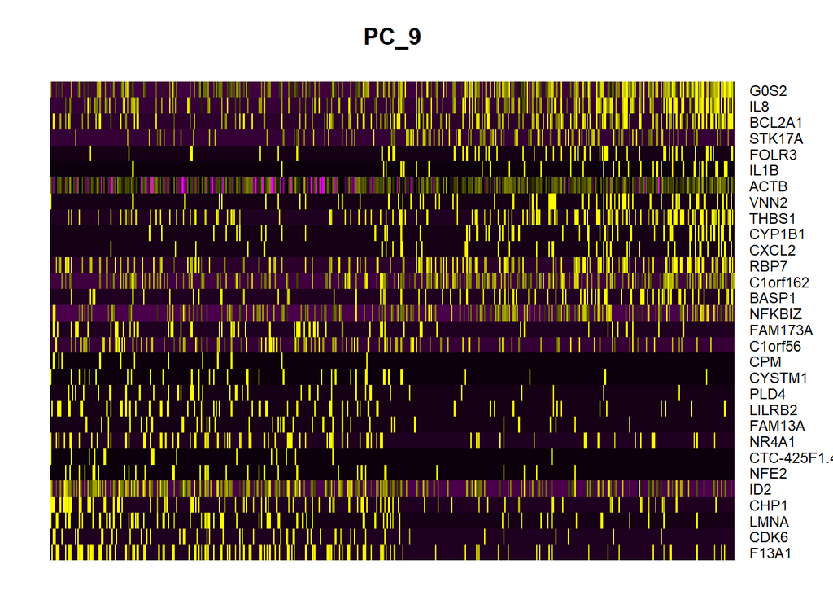

```r
DimHeatmap(object = cbmc, dims = 9, cells = 500, balanced = TRUE)
```

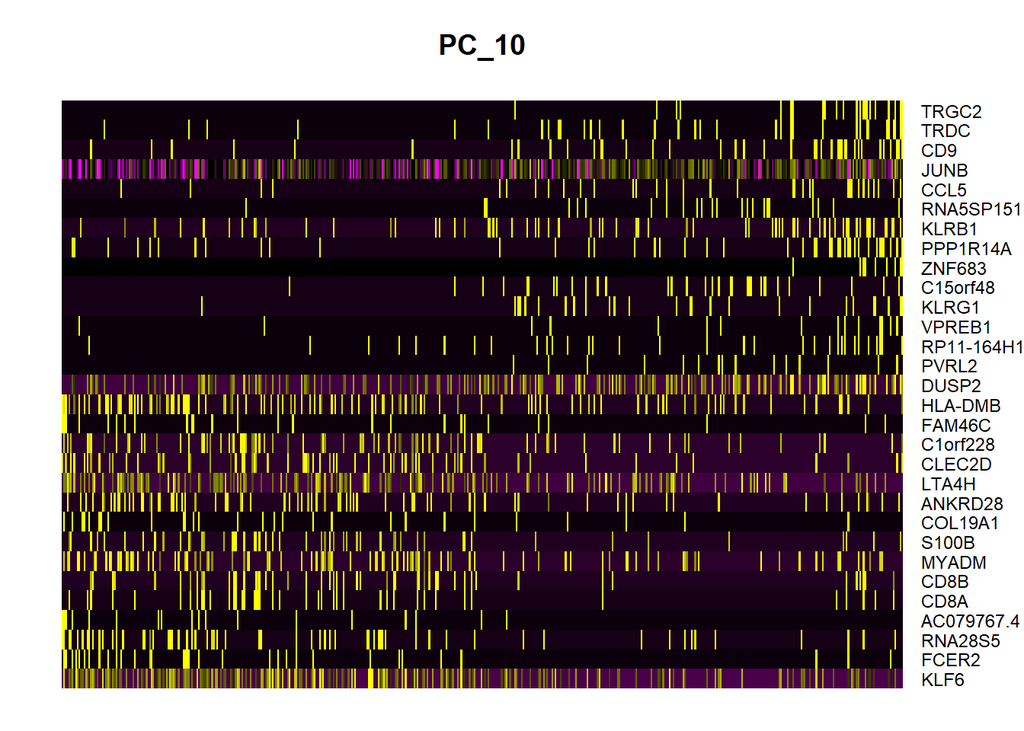

```r
DimHeatmap(object = cbmc, dims = 10, cells = 500, balanced = TRUE)
```

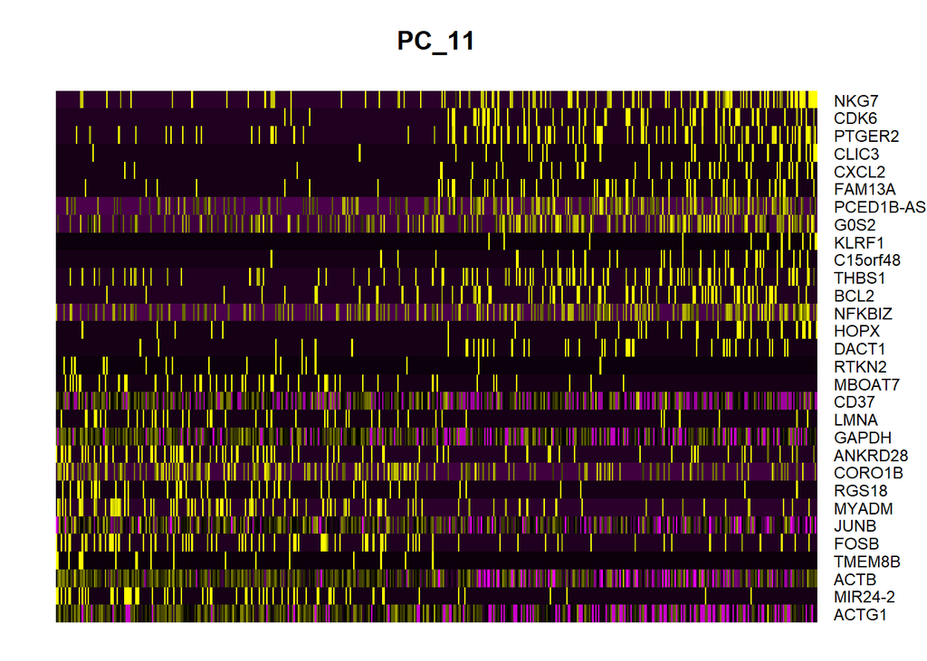

```r
DimHeatmap(object = cbmc, dims = 11, cells = 500, balanced = TRUE)
```

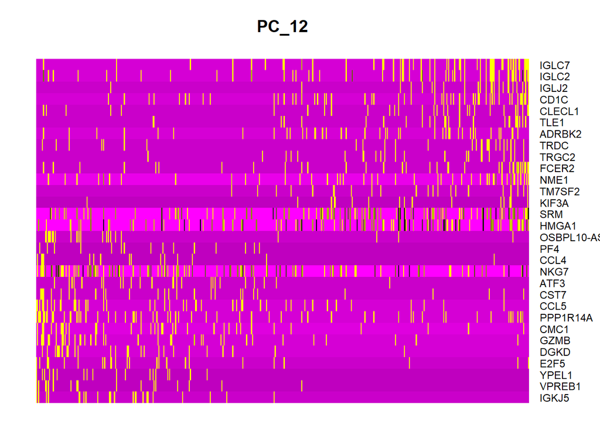

```r
DimHeatmap(object = cbmc, dims = 12, cells = 500, balanced = TRUE)
```

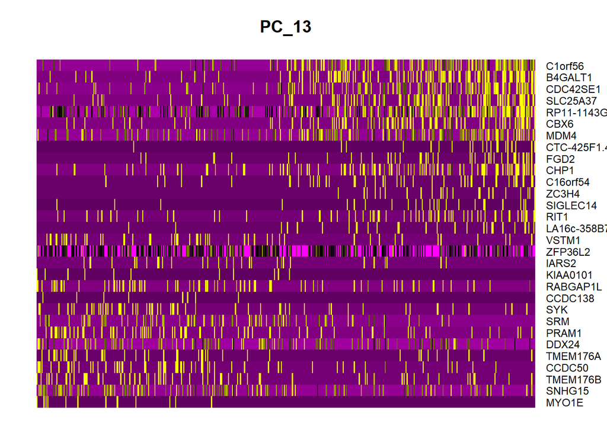

```r
DimHeatmap(object = cbmc, dims = 13, cells = 500, balanced = TRUE)
```

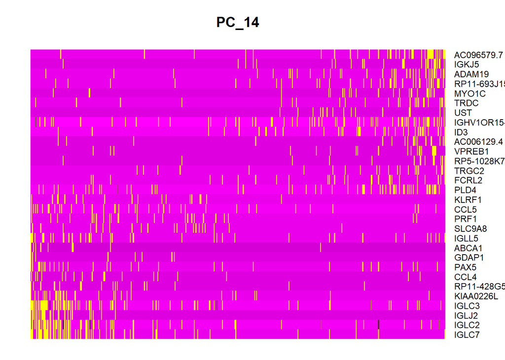

```r
DimHeatmap(object = cbmc, dims = 14, cells = 500, balanced = TRUE)
```

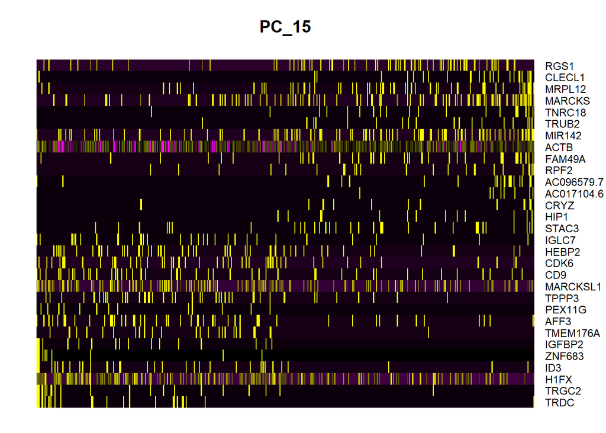

```r
DimHeatmap(object = cbmc, dims = 15, cells = 500, balanced = TRUE)
```

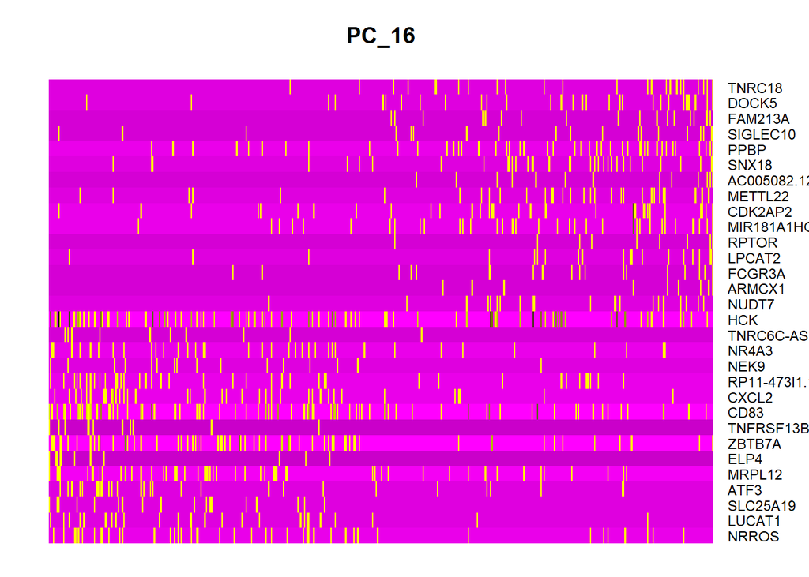

```r
DimHeatmap(object = cbmc, dims = 16, cells = 500, balanced = TRUE)
```

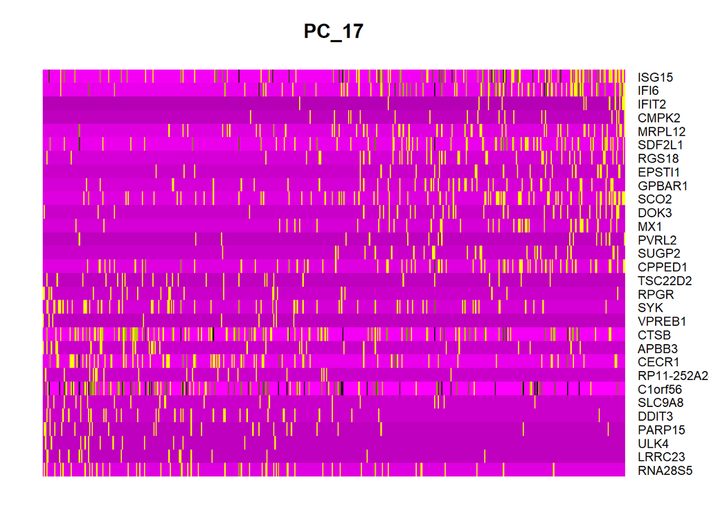

```r
DimHeatmap(object = cbmc, dims = 17, cells = 500, balanced = TRUE)
```

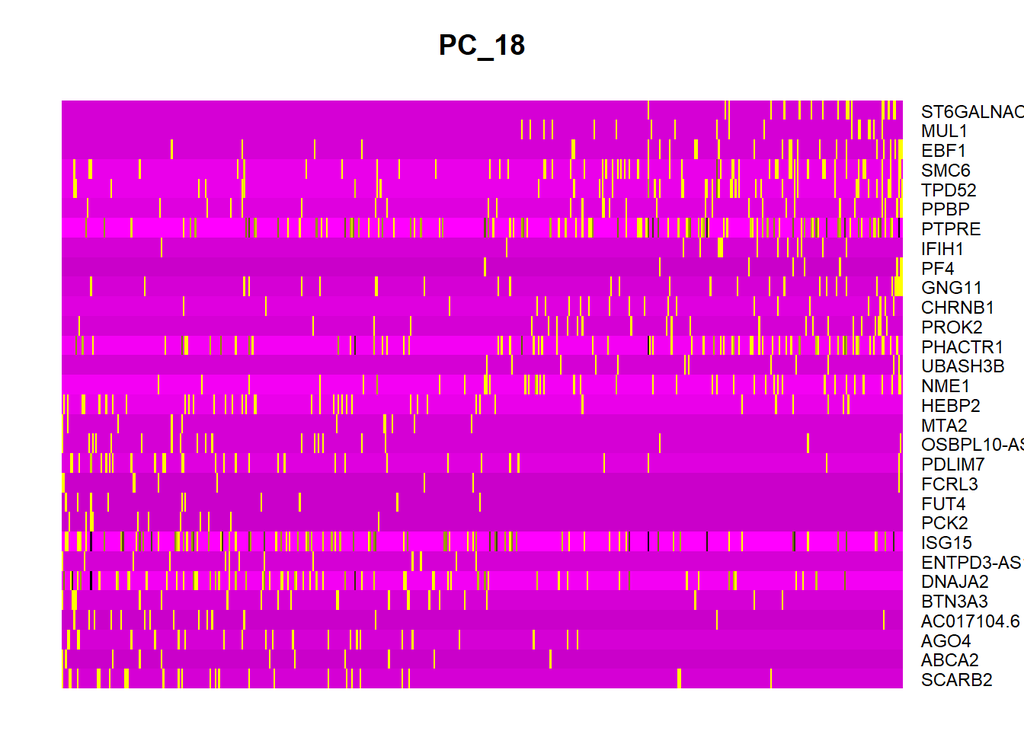

```r
DimHeatmap(object = cbmc, dims = 18, cells = 500, balanced = TRUE)
```

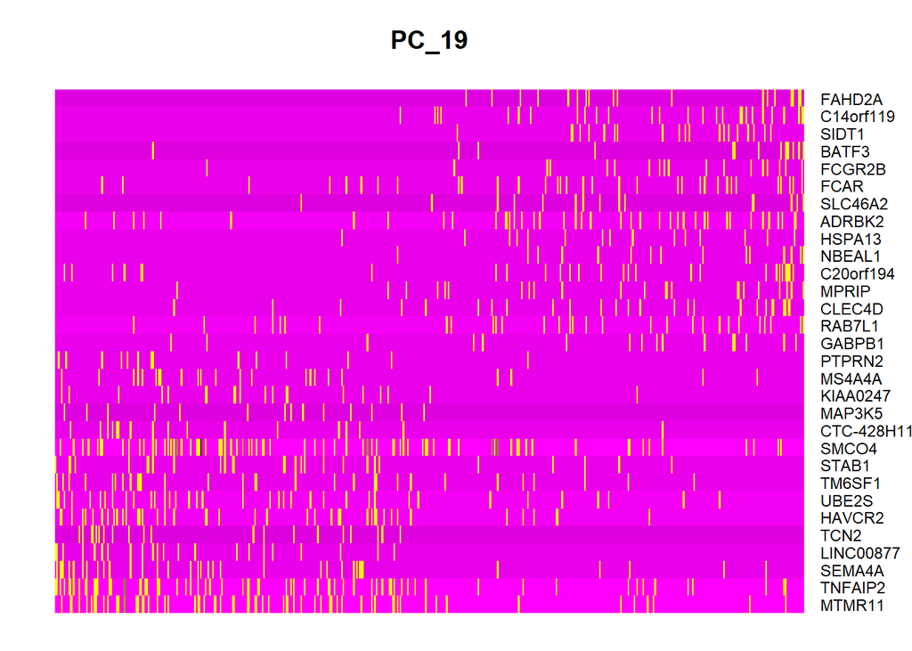

```r
DimHeatmap(object = cbmc, dims = 19, cells = 500, balanced = TRUE)
```

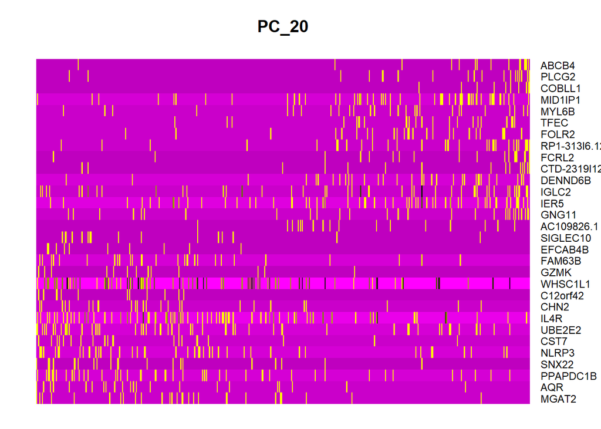

```r
DimHeatmap(object = cbmc, dims = 20, cells = 500, balanced = TRUE)
```

We decided in the previous step to limit the dimensions to 10 points. # Cluster the cells The number of calculated communities - 6 The number of clusters depends on the resolution. Therefore, we can use it to increase or decrease the number of clusters. This parameter depends on the depth of analysis of the cells. Because not always will there be different cells in different clusters.

```r
#find neighbours and cluster the cells
cbmc <- FindNeighbors(object = cbmc, dims = 1:10)
cbmc <- FindClusters(object = cbmc, resolution = 0.5)
```

```
## Modularity Optimizer version 1.3.0 by Ludo Waltman and Nees Jan van Eck
##
## Number of nodes: 2390
## Number of edges: 85025
##
## Running Louvain algorithm...
## Maximum modularity in 10 random starts: 0.8685
## Number of communities: 6
## Elapsed time: 0 seconds
```

## Run Non-linear dimensional reduction (tSNE)

Compressing of a file in 2 dimensions.

```r
#run tsne
cbmc <- RunTSNE(object = cbmc, dims = 1:10)
```

According to this figure, it is difficult to say how the clusters relate to each other, for example, cluster 1 to cluster 0.

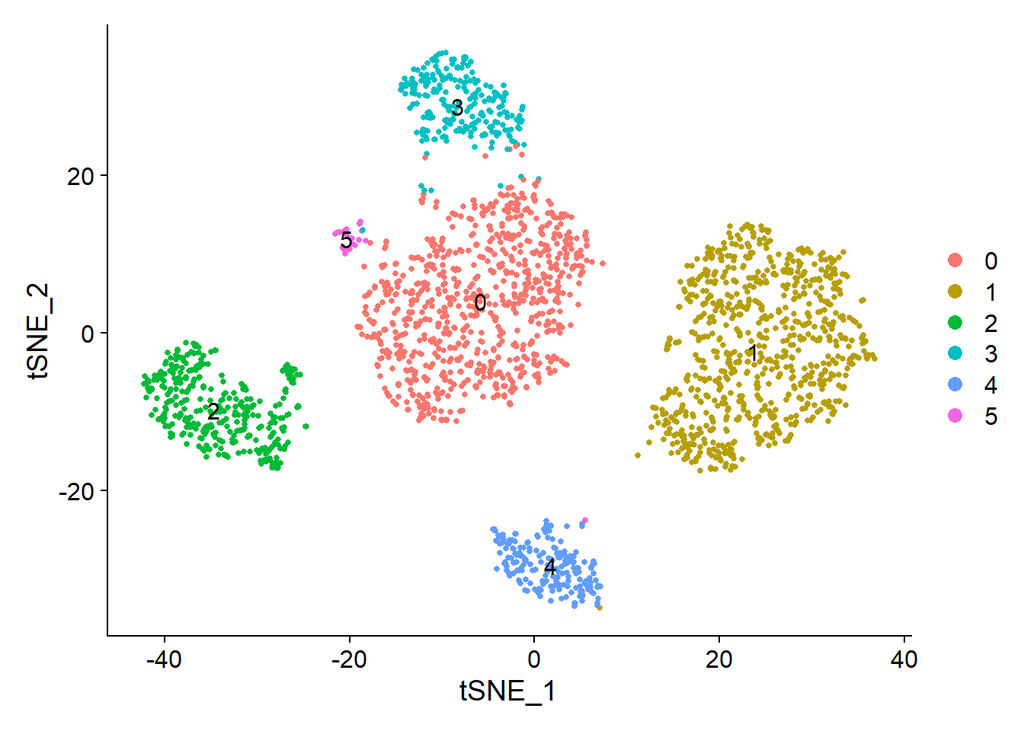

```r
#look how shitty it looks
DimPlot(cbmc, reduction = 'tsne', label = TRUE, pt.size = 1)
```

A technique umap that better displays the relationship between clusters.

```r
#run umap
cbmc <- RunUMAP(cbmc, dims = 1:10)
```

By the distance between clusters, we can say that cluster 0 is more related to cluster 3 than to cluster 2. This umap technology is more preferable than dimplot.

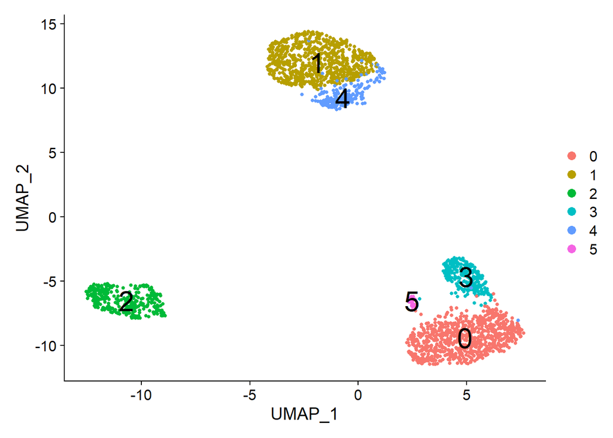

```r
#what a beautiful UMAP!
DimPlot(cbmc, reduction = 'umap', label = TRUE, pt.size = 1, label.size = 8)
```